# Euros Project Sven

Sven Jolivet

2023-11-29

# Introduction

In the dynamic world of soccer, where every pass, sprint, and strategic move can influence the outcome of a game, the distance covered by a team throughout a match doesn’t emerge as a pivotal metric. The modern game demands a a blend of skill, teamwork, and relentless physical effort. The distance traveled on the field is not merely a statistical figure but a reflection of the collective energy, endurance, and tactical acumen of the players.

# Questions

Does running around the field more prompt you to shoot more?

Did running more effect who the tournaments winner was?

# Packages

# Unfiltered Data

My data is from data.world and the author is Mikhail Zhilkin.

https://data.world/cervus/uefa-euro-2020/workspace/file?filename=Match+team+statistics.csv

```
## Rows: 19,194
## Columns: 11
## $ MatchID      <dbl> 2024442, 2024442, 2024442, 2024442, 2024442, 2024442, 202…
## $ HomeTeamName <chr> "Austria", "Austria", "Austria", "Austria", "Austria", "A…
## $ AwayTeamName <chr> "North Macedonia", "North Macedonia", "North Macedonia", …
## $ TeamID       <dbl> 8, 8, 8, 8, 8, 8, 8, 8, 8, 8, 8, 8, 8, 8, 8, 8, 8, 8, 8, …
## $ TeamName     <chr> "Austria", "Austria", "Austria", "Austria", "Austria", "A…
## $ IsHomeTeam   <lgl> TRUE, TRUE, TRUE, TRUE, TRUE, TRUE, TRUE, TRUE, TRUE, TRU…
## $ IsAwayTeam   <lgl> FALSE, FALSE, FALSE, FALSE, FALSE, FALSE, FALSE, FALSE, F…
## $ StatsID      <dbl> 1, 2, 3, 4, 5, 6, 11, 12, 13, 14, 17, 18, 19, 20, 21, 22,…
## $ StatsName    <chr> "Goals", "Ball Possession", "Total Attempts", "Attempts o…
## $ Value        <chr> "3", "60", "11", "7", "2", "0", "64", "4", "1", "1", "7",…
## $ Rank         <dbl> 1, 1, 1, 1, 2, 1, 1, 1, 1, 2, 1, 2, 1, 2, 2, 1, 1, 1, 1, …
```

# Filtering

Having 19,000 rows is pretty overwhelming and a lot of the data is not useful so I narrowed it down to key factors that I will be looking for.

TeamName: Is the Name of the Team

StatsName: The specific stat that we are talking about

MatchID: The specific match that was played

Value: The numerical value for StatsName

Distance: The distance a team ran

Shots: The amount of shots attempted

```
## Rows: 19,194
## Columns: 4
## $ TeamName  <chr> "Austria", "Austria", "Austria", "Austria", "Austria", "Aust…
## $ StatsName <chr> "Goals", "Ball Possession", "Total Attempts", "Attempts on t…
## $ Value     <chr> "3", "60", "11", "7", "2", "0", "64", "4", "1", "1", "7", "7…
## $ MatchID   <dbl> 2024442, 2024442, 2024442, 2024442, 2024442, 2024442, 202444…
```

# Total Distance

Finding the distance each team achieved during each of their games.

The netherlands had the lowest distance ran in a game and Italy had the highest.

| TeamName | Value |
| --- | --- |
| Netherlands | 84035 |
| Ukraine | 84426 |
| Switzerland | 87266 |
| Wales | 90283 |
| Croatia | 96615 |
| Netherlands | 97399 |
| Wales | 97930 |
| France | 99295 |
| France | 99947 |
| England | 100013 |
| Slovakia | 100735 |
| Denmark | 100789 |
| Croatia | 101193 |
| Italy | 101245 |
| Wales | 101448 |
| Finland | 101741 |
| Portugal | 102281 |
| Turkey | 102849 |
| North Macedonia | 103238 |
| Portugal | 103330 |
| Turkey | 103358 |
| England | 104370 |
| Croatia | 104729 |
| Belgium | 104735 |
| Poland | 104791 |
| Finland | 104798 |
| Scotland | 105151 |
| Portugal | 105157 |
| Ukraine | 105276 |
| Denmark | 105354 |

[output cut: 70 more lines]

# Comparing Distances

Since it is a tournament not all teams play the same amount of games, so I needed to take the average of the games they did play in order to compare them.

# Finalists

As you can see the the finalist did run more than 2 teams that were eleminated earlier into the tournament.

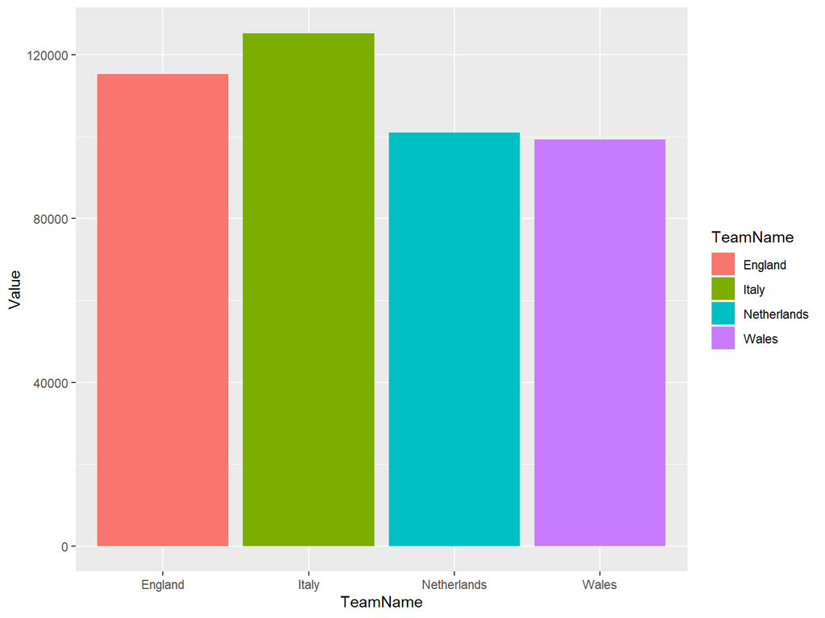

# Total Attempts

| TeamName | Value |
| --- | --- |
| Finland | 0 |
| Finland | 1 |
| Russia | 1 |
| Wales | 3 |
| Slovakia | 3 |
| Turkey | 3 |
| France | 4 |
| Sweden | 4 |
| Russia | 5 |
| England | 5 |
| England | 5 |
| Hungary | 5 |
| Hungary | 5 |
| Poland | 5 |
| Ukraine | 5 |
| Belgium | 6 |
| Belgium | 6 |
| Denmark | 6 |
| England | 6 |
| Switzerland | 6 |
| North Macedonia | 7 |
| Czech Republic | 7 |
| Finland | 7 |
| Italy | 7 |
| Netherlands | 7 |
| Ukraine | 7 |
| England | 8 |
| Croatia | 8 |
| Hungary | 8 |
| Austria | 8 |

[output cut: 70 more lines]

# Distance Vs Shots Attempted

Does running around the field more prompt you to shoot more?

I took the average shots attempted for each country and joined the average distance together. In order to see if there is a trend between the two factors.

| TeamName | Value |
| --- | --- |
| Austria | 13.250000 |
| Belgium | 9.600000 |
| Croatia | 10.500000 |
| Czech Republic | 11.400000 |
| Denmark | 16.000000 |
| England | 9.142857 |
| Finland | 2.666667 |
| France | 14.250000 |
| Germany | 12.000000 |
| Hungary | 6.000000 |
| Italy | 18.285714 |
| Netherlands | 13.250000 |
| North Macedonia | 10.666667 |
| Poland | 13.333333 |
| Portugal | 13.250000 |
| Russia | 3.000000 |
| Scotland | 14.000000 |
| Slovakia | 8.000000 |
| Spain | 18.500000 |
| Sweden | 10.500000 |
| Switzerland | 13.800000 |
| Turkey | 13.000000 |
| Ukraine | 10.400000 |
| Wales | 9.750000 |

| TeamName | Shots | Distance |
| --- | --- | --- |
| Austria | 13.250000 | 118598.5 |
| Belgium | 9.600000 | 107839.6 |
| Croatia | 10.500000 | 107790.0 |
| Czech Republic | 11.400000 | 113966.6 |
| Denmark | 16.000000 | 112203.4 |
| England | 9.142857 | 115272.3 |
| Finland | 2.666667 | 105874.0 |
| France | 14.250000 | 110568.8 |
| Germany | 12.000000 | 107867.2 |
| Hungary | 6.000000 | 108803.0 |
| Italy | 18.285714 | 125304.1 |
| Netherlands | 13.250000 | 101098.2 |
| North Macedonia | 10.666667 | 106212.7 |
| Poland | 13.333333 | 106669.7 |
| Portugal | 13.250000 | 104478.2 |
| Russia | 3.000000 | 117234.0 |
| Scotland | 14.000000 | 107562.3 |
| Slovakia | 8.000000 | 105248.7 |
| Spain | 18.500000 | 127222.7 |
| Sweden | 10.500000 | 119075.0 |
| Switzerland | 13.800000 | 115899.6 |
| Turkey | 13.000000 | 103986.7 |
| Ukraine | 10.400000 | 109413.2 |
| Wales | 9.750000 | 99291.0 |

# Chart

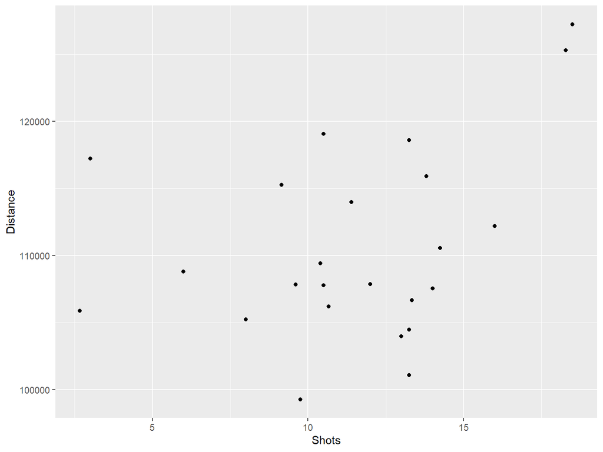

# Summary